# Lab 2: Data Wrangling With Dplyr

Melissa Melton

9/27/2022

# Setup

```r
library(tidyverse)
```

```r
hiphop <- read.csv('hiphop.csv')
```

# Summary

```r
hiphop %>%
  summary()
```

```
##      word               subj               sex                 age
##  Length:10752       Length:10752       Length:10752       Min.   :16.00
##  Class :character   Class :character   Class :character   1st Qu.:18.00
##  Mode  :character   Mode  :character   Mode  :character   Median :19.00
##                                                           Mean   :20.02
##                                                           3rd Qu.:20.00
##                                                           Max.   :48.00
##
##     ethnic               city             county             intl
##  Length:10752       Min.   :      0   Min.   :      0   Min.   : 0.0000
##  Class :character   1st Qu.:  12807   1st Qu.:  99905   1st Qu.: 0.0000
##  Mode  :character   Median :  42322   Median : 331582   Median : 0.0000
##                     Mean   : 159130   Mean   : 509217   Mean   : 0.3869
##                     3rd Qu.: 103486   3rd Qu.: 959521   3rd Qu.: 0.0000
##                     Max.   :8391881   Max.   :3053793   Max.   :15.0000
##
##      vocal          classical            folk             rock
##  Min.   : 0.000   Min.   : 0.0000   Min.   :0.0000   Min.   : 0.000
##  1st Qu.: 0.000   1st Qu.: 0.0000   1st Qu.:0.0000   1st Qu.: 0.000
##  Median : 0.000   Median : 0.0000   Median :0.0000   Median : 1.000
##  Mean   : 1.089   Mean   : 0.8095   Mean   :0.3988   Mean   : 2.274
##  3rd Qu.: 1.000   3rd Qu.: 0.0000   3rd Qu.:0.0000   3rd Qu.: 4.000
##  Max.   :11.000   Max.   :10.0000   Max.   :6.0000   Max.   :18.000
##
##     country            pop          alternative         hiphop
##  Min.   :0.0000   Min.   : 0.000   Min.   : 0.000   Min.   : 0.000
##  1st Qu.:0.0000   1st Qu.: 0.000   1st Qu.: 0.000   1st Qu.: 0.000
##  Median :0.0000   Median : 1.000   Median : 2.000   Median : 0.000
##  Mean   :0.6667   Mean   : 1.238   Mean   : 2.196   Mean   : 1.595
##  3rd Qu.:0.0000   3rd Qu.: 2.000   3rd Qu.: 4.000   3rd Qu.: 3.000
##  Max.   :7.0000   Max.   :11.000   Max.   :13.000   Max.   :10.000
##
##  unclassifiable     countyBlack          jayz          barkley
##  Min.   :0.00000   Min.   :     0   Min.   :1.000   Min.   :1.000
##  1st Qu.:0.00000   1st Qu.:   675   1st Qu.:1.000   1st Qu.:1.000
##  Median :0.00000   Median :  7748   Median :5.000   Median :1.000
##  Mean   :0.05357   Mean   : 46404   Mean   :3.839   Mean   :1.804
##  3rd Qu.:0.00000   3rd Qu.: 50842   3rd Qu.:5.000   3rd Qu.:3.000
##  Max.   :1.00000   Max.   :942470   Max.   :5.000   Max.   :5.000
##
```

[output cut: 25 more lines]

```
##  Min.   :1.000   Min.   : 1.00   Min.   :0.00   Min.   :  0.00
##  1st Qu.:1.000   1st Qu.:16.75   1st Qu.:0.00   1st Qu.:  0.00
##  Median :1.000   Median :32.50   Median :0.00   Median : 21.00
##  Mean   :1.818   Mean   :32.50   Mean   :0.24   Mean   : 27.64
##  3rd Qu.:1.000   3rd Qu.:48.25   3rd Qu.:0.00   3rd Qu.: 42.50
##  Max.   :5.000   Max.   :64.00   Max.   :1.00   Max.   :120.00
##
##  numPreferredArtists numOverallArtists
##  Min.   :0.000       Min.   : 0.000
##  1st Qu.:0.000       1st Qu.: 0.000
##  Median :0.000       Median : 3.000
##  Mean   :0.338       Mean   : 5.953
##  3rd Qu.:0.000       3rd Qu.: 8.000
##  Max.   :6.000       Max.   :28.000
##  NA's   :5632        NA's   :5632
```

This dataset contains a dependent variable called familiarity, which ranks a participant’s familiarity with a particular African American Vernacular English (AAVE) word/phrase on a scale from 1 to 5. It includes demographic data on the participants in the study, including their sex, age, race, and where they are from. There are also variables representing participants’ frequency of interaction with Black individuals, their music preferences. The AAVE words participants were tested on are also, of course, included in this dataset, as well as data on the word’s popularity and famous musicians who have used it, and the participants’ familiarity with the words. Some variables, such as participants’ responses to questions about pop culture, have boolean equivalents, usually representing to what extent the participant correctly answered the question.

```r
# Not choosing to drop NA values for now, as it would drop nearly half the observations

# Convert sex to factor

hiphop <- hiphop %>%
  mutate(sex = as.factor(sex))
```

```r
length(unique(hiphop$word))
```

```
## [1] 64
```

64 unique AAVE words were studied in this dataset.

```r
hiphop <- hiphop %>%
  mutate(white = ifelse(ethnic == 'white', 'white', 'nonwhite'))
```

```r
hiphop_demog <- hiphop %>%
  distinct(subj, .keep_all = TRUE) %>%
  select(subj, age, sex, ethnic)

summary(hiphop_demog)
```

```
##      subj                age            sex         ethnic
##  Length:168         Min.   :16.00   Female:117   Length:168
##  Class :character   1st Qu.:18.00   Male  : 51   Class :character
##  Mode  :character   Median :19.00                Mode  :character
##                     Mean   :20.02
##                     3rd Qu.:20.00
##                     Max.   :48.00
```

```r
table(hiphop_demog$ethnic)/nrow(hiphop_demog)
```

```
##
##     african       asian    biracial       black    hispanic      indian
## 0.029761905 0.113095238 0.005952381 0.005952381 0.017857143 0.011904762
##      native     unknown       white
## 0.005952381 0.005952381 0.803571429
```

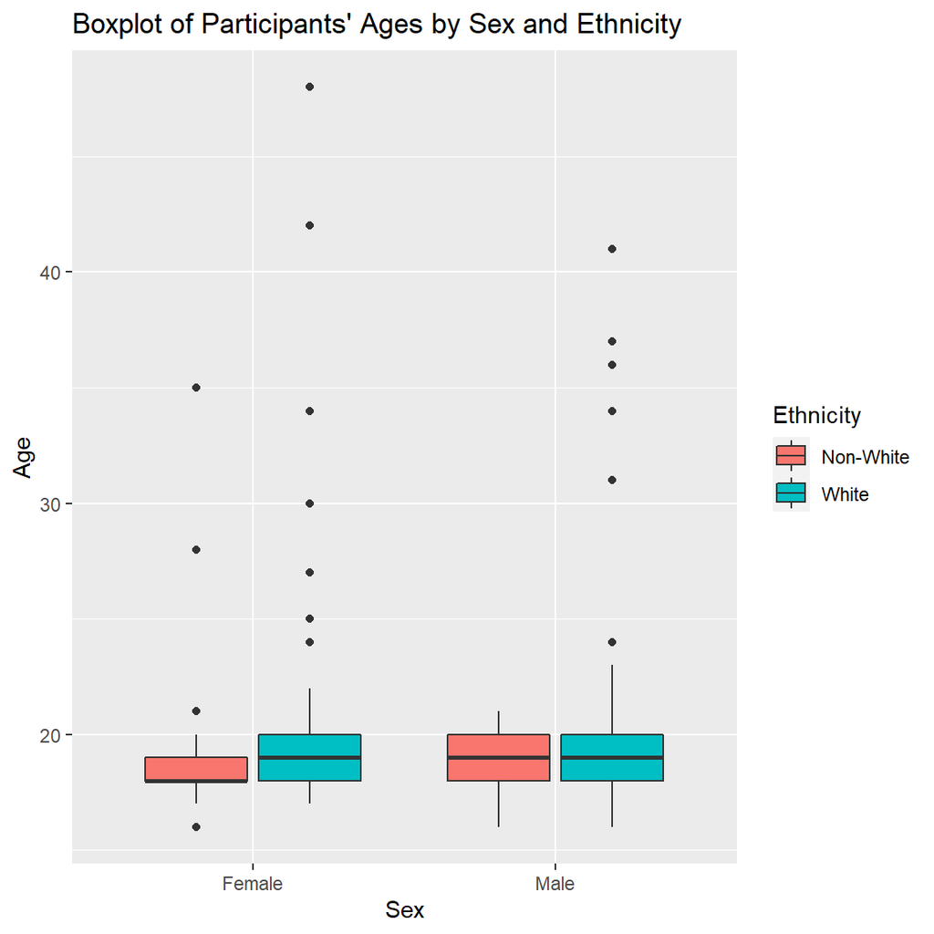

```r
hiphop %>%
  ggplot(aes(x= sex, y=age, fill=white)) +
  geom_boxplot() +
  xlab('Sex') +
  ylab('Age') +
  scale_fill_discrete(name = 'Ethnicity', labels = c('Non-White', 'White')) +
  labs(title = "Boxplot of Participants' Ages by Sex and Ethnicity")
```

[figure not shown]

```r
hiphop %>%
  ggplot(aes(x = ethnic, fill = ethnic)) +
  geom_bar() +
  scale_y_continuous(name = 'Count', trans='log10') +
  scale_fill_discrete(name = 'Ethnicity', labels = c('African', 'Asian', 'Biracial', 'Black', 'Hispanic', 'Indian', 'Native', 'Unknown', 'White')) +
  theme(axis.text.x = element_blank(), axis.ticks.x = element_blank()) +
  xlab('') +
  ggtitle('Number of Participants by Ethnicity')
```

# Familiar Words

```r
# average familiarity of each word for people < 20
(hiphop %>%
  mutate(as.factor(word)) %>%
  filter(age < 20) %>%
  group_by(word) %>%
  mutate(avg_fam = mean(familiarity))%>%
  select(word, avg_fam) %>%
  unique() %>%
  arrange(avg_fam))[c(1,64),]
```

```
## # A tibble: 2 × 2
## # Groups:   word [2]
##   word             avg_fam
##   <chr>              <dbl>
## 1 catch the vapors    1.03
## 2 off the hook        4.42
```

```r
# average familiarity of each word for non-white women
# break someone out, dukey rope, plex, and rollie tied for least familiar

(hiphop %>%
  mutate(as.factor(word)) %>%
  filter(ethnic != 'white' & sex == 'Female') %>%
  group_by(word) %>%
  mutate(avg_fam = mean(familiarity))%>%
  select(word, avg_fam) %>%
  unique() %>%
  arrange(avg_fam))[c(1:4,64),]
```

```
## # A tibble: 5 × 2
## # Groups:   word [5]
##   word              avg_fam
##   <chr>               <dbl>
## 1 break someone out    1
## 2 dukey rope           1
## 3 plex                 1
## 4 rollie               1
## 5 feel me              4.19
```

```r
# tons of ties for least familiar!
(hiphop %>%
  mutate(as.factor(word)) %>%
  filter(age > 30 & sex == 'Male' & ethnic == 'white') %>%
  group_by(word) %>%
  mutate(avg_fam = mean(familiarity))%>%
  select(word, avg_fam) %>%
  unique() %>%
  arrange(avg_fam))[c(1:15,64),]
```

```
## # A tibble: 16 × 2
## # Groups:   word [16]
##    word              avg_fam
##    <chr>               <dbl>
##  1 ay yo trip            1
##  2 beezy                 1
##  3 break someone out     1
##  4 catch the vapors      1
##  5 crossroads            1
##  6 crump                 1
##  7 dap                   1
##  8 dollar cab            1
##  9 domino                1
## 10 duckets               1
## 11 face gator            1
## 12 fetti                 1
## 13 finna                 1
## 14 ghostride             1
## 15 good hair             1
## 16 5-0                   4.2
```

There are interesting differences in familiarity with AAVE words/phrases among these three groups. For people below the age of 20, the least familiar word is “catch the vapors” while the most familiar is “off the hook”. Among non-white women, the least familiar word is a tie between “break someone out”, “dukey rope”, “plex”, and “rollie”, while the most familiar word is “feel me”. Among white men older than 30, too many words to list were tied with a minimum average familiarity score of 1! Among this group, the most familiar word was “5-0”.

Here, to calculate differences in mean number of artists listed for each genre between the two demographic groups, I first converted the data to long format to get a genre variable and the mean count for each genre, by demographic group. Then I converted it to wide format to compute the average differences between each demographic group for each genre.

```r
# difference between mean number of artists listed (female - male)
hiphop %>%
  group_by(sex) %>%
  summarize(across(intl:unclassifiable, mean)) %>%
  pivot_longer(intl:unclassifiable,
               names_to = 'Genre',
               values_to = 'Mean_Count') %>%
  group_by(Genre, sex) %>%
  pivot_wider(names_from = sex,
              values_from = Mean_Count,
              names_prefix = 'GenreMean_') %>%
  mutate(GenreMean_Diff = GenreMean_Female - GenreMean_Male)%>%
  arrange(GenreMean_Diff)
```

```
## # A tibble: 10 × 4
## # Groups:   Genre [10]
##    Genre          GenreMean_Female GenreMean_Male GenreMean_Diff
##    <chr>                     <dbl>          <dbl>          <dbl>
##  1 rock                     1.93           3.06         -1.13
##  2 vocal                    0.880          1.57         -0.688
##  3 classical                0.752          0.941        -0.189
##  4 folk                     0.402          0.392         0.00955
##  5 unclassifiable           0.0598         0.0392        0.0206
##  6 alternative              2.21           2.16          0.0568
##  7 hiphop                   1.62           1.53          0.0945
##  8 intl                     0.444          0.255         0.190
##  9 pop                      1.30           1.10          0.201
## 10 country                  0.786          0.392         0.394
```

The genre with the greatest difference in popularity among men and women is rock, with men in this study reporting, on average, 1.13 more rock artists they listen to than women.

```r
# difference between mean number of artists listed (white - nonwhite)
hiphop %>%
  group_by(white) %>%
  summarize(across(intl:unclassifiable, mean)) %>%
  pivot_longer(intl:unclassifiable,
               names_to = 'Genre',
               values_to = 'Mean_Count') %>%
  group_by(Genre, white) %>%
  pivot_wider(names_from = white,
              values_from = Mean_Count,
              names_prefix = 'GenreMean_') %>%
  mutate(GenreMean_Diff = GenreMean_white - GenreMean_nonwhite)%>%
  arrange(GenreMean_Diff)
```

```
## # A tibble: 10 × 4
## # Groups:   Genre [10]
##    Genre          GenreMean_nonwhite GenreMean_white GenreMean_Diff
##    <chr>                       <dbl>           <dbl>          <dbl>
##  1 intl                       1.67            0.0741        -1.59
##  2 hiphop                     2.18            1.45          -0.730
##  3 classical                  0.848           0.8           -0.0485
##  4 unclassifiable             0.0909          0.0444        -0.0465
##  5 pop                        1.27            1.23          -0.0431
##  6 folk                       0.182           0.452          0.270
##  7 country                    0.273           0.763          0.490
##  8 vocal                      0.667           1.19           0.526
##  9 alternative                1.24            2.43           1.19
## 10 rock                       1.06            2.57           1.51
```

```r
# difference between mean number of artists listed (below 21 - above 21)
hiphop %>%
  mutate(age_21 = ifelse(age < 21, 'below_21', 'above_21')) %>%
  group_by(age_21) %>%
  summarize(across(intl:unclassifiable, mean)) %>%
  pivot_longer(intl:unclassifiable,
               names_to = 'Genre',
               values_to = 'Mean_Count') %>%
  group_by(Genre, age_21) %>%
  pivot_wider(names_from = age_21,
              values_from = Mean_Count,
              names_prefix = 'GenreMean_') %>%
  mutate(GenreMean_Diff = GenreMean_below_21 - GenreMean_above_21)%>%
  arrange(GenreMean_Diff)
```

```
## # A tibble: 10 × 4
## # Groups:   Genre [10]
##    Genre          GenreMean_above_21 GenreMean_below_21 GenreMean_Diff
##    <chr>                       <dbl>              <dbl>          <dbl>
##  1 alternative                2.5                2.12          -0.381
##  2 classical                  0.882              0.791         -0.0913
##  3 rock                       2.32               2.26          -0.0623
##  4 unclassifiable             0.0882             0.0448        -0.0435
##  5 folk                       0.412              0.396         -0.0162
##  6 country                    0.676              0.664         -0.0123
##  7 pop                        1.21               1.25           0.0404
##  8 vocal                      0.941              1.13           0.186
##  9 hiphop                     1.35               1.66           0.304
## 10 intl                       0.118              0.455          0.338
```

The genre with the largest difference in popularity among participants above and below 21 years old is alternative. On average, participants above 21 listed 0.38 more alternative artists than participants below 21. Also, international music and hip hop music appear to be more popular with younger audiences than older audiences.

# Use the Data

```r
aboveavg_hh_artists <- quantile(hiphop$hiphop, .75) # 3 or more hip hop artists were listed in 25% of trials
#I would assume the people who listed 3 or more artists tend to be bigger hip hop fans

# filter results to find hip hop words most recognized among the people who listen to the most hip hop artists
hiphop %>%
  filter(hiphop >= aboveavg_hh_artists) %>%
  group_by(word) %>%
  mutate(avg_fam = mean(familiarity)) %>%
  select(word, avg_fam) %>%
  unique()%>%
  arrange(desc(avg_fam))
```

```
## # A tibble: 64 × 2
## # Groups:   word [64]
##    word         avg_fam
##    <chr>          <dbl>
##  1 feel me         4.43
##  2 off the hook    4.32
##  3 hella           4.23
##  4 what it do      3.70
##  5 boo             3.66
##  6 finna           3.45
##  7 make it rain    3.34
##  8 ashy            3.19
##  9 What it is?     3.11
## 10 5-0             2.87
## # … with 54 more rows
```

Based on the word familiarity of individuals that listed the most hip hop artists they listen to, I would recommend that Aubrey include words and phrases such as: ‘feel me’, ‘off the hook’, ‘hella’, ‘what it do’, ‘boo’, and ‘finna’. I’d advise he avoid the words and phrases ‘dollar cab’, ‘humming’, ‘The Nation’, ‘break someone out’, and ‘domino’, as these are less recognizable among hip hop fans.

```r
hiphop %>%
  select(city) %>%
  summary()
```

```
##       city
##  Min.   :      0
##  1st Qu.:  12807
##  Median :  42322
##  Mean   : 159130
##  3rd Qu.: 103486
##  Max.   :8391881
```

```r
# label each city as low, medium, or high population based on percentile
hiphop$cityBinned <- cut(hiphop$city,
                         breaks = quantile(hiphop$city, probs = seq(0,1, by = 1/3)),
                         labels = c('low', 'medium', 'high'),
                         include.lowest= TRUE,
                         right = FALSE)

#table(hiphop$cityBinned)
```

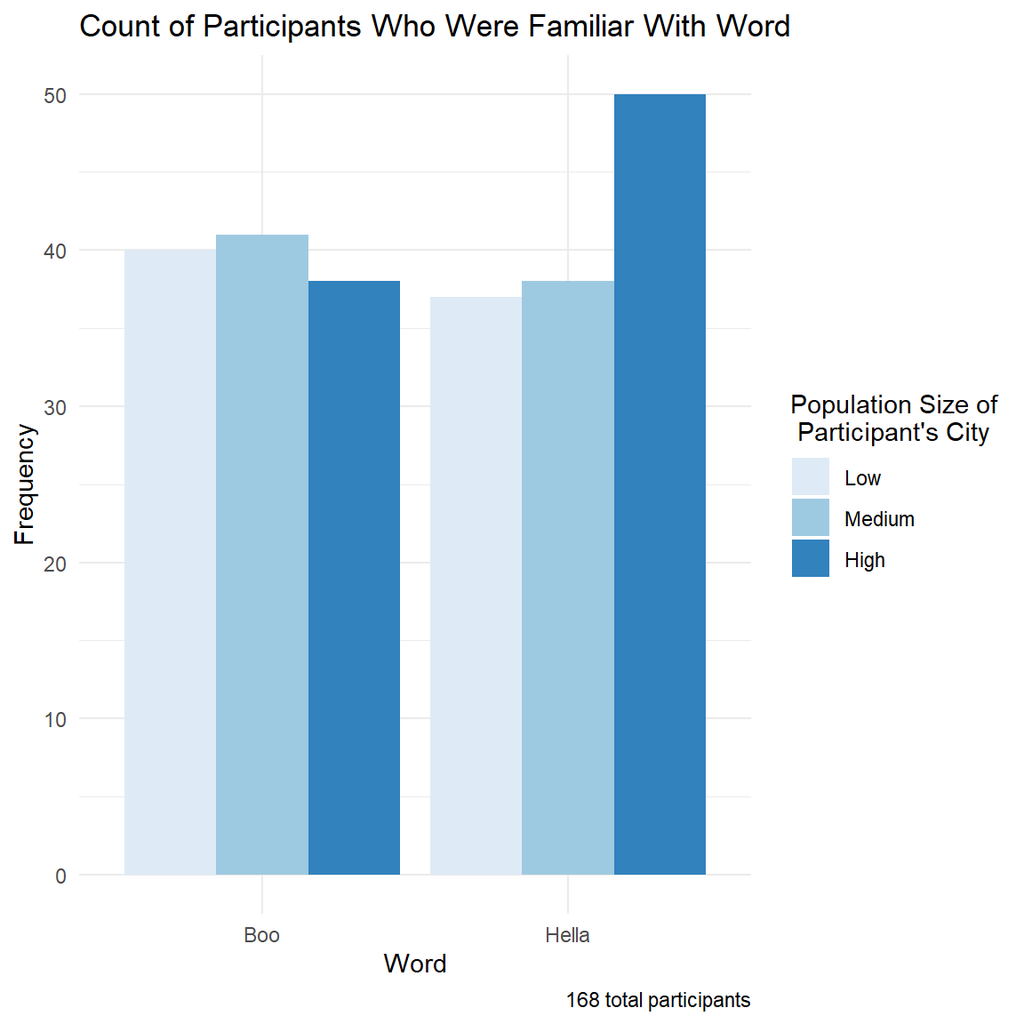

```r
hiphop %>%
  filter(word %in% c('boo', 'hella')) %>%
  select(c('word', 'fam1', 'cityBinned'))%>%
  group_by(word, cityBinned) %>%
  summarize(Frequency = sum(fam1)) %>%
  ggplot(aes(x= word, y = Frequency, fill=cityBinned)) +
  geom_bar(stat='identity', position=position_dodge()) +
  theme_minimal() +
  scale_fill_brewer(name = "Population Size of\n Participant's City", palette = 'Blues', labels = c('Low', 'Medium', 'High')) +
  scale_x_discrete(name = 'Word', labels = c('Boo', 'Hella')) +
  ggtitle('Count of Participants Who Were Familiar With Word') +
  labs(caption = '168 total participants')
```

I would recommend Aubrey use the title “Hella Bling” over the title “Hotline Boo” if he wants to appeal more to the higher population areas.

```r
hiphop %>%
  filter(sex == 'Male') %>%
  filter(city >= 10000 & city <= 60000) %>%
  filter(age >= 17 & age <= 23) %>%
  filter(bieber == 5.0) %>%
  head()
```

```
##            word subj  sex age ethnic  city county intl vocal classical folk
## 1 [to be] ghost  p17 Male  18  white 56377 331582    0     1         0    0
## 2           5-0  p17 Male  18  white 56377 331582    0     1         0    0
## 3        A-town  p17 Male  18  white 56377 331582    0     1         0    0
## 4          ashy  p17 Male  18  white 56377 331582    0     1         0    0
## 5    ay yo trip  p17 Male  18  white 56377 331582    0     1         0    0
## 6       ballin'  p17 Male  18  white 56377 331582    0     1         0    0
##   rock country pop alternative hiphop unclassifiable countyBlack jayz barkley
## 1    1       0   3           4      1              0       13160    5       1
## 2    1       0   3           4      1              0       13160    5       1
## 3    1       0   3           4      1              0       13160    5       1
## 4    1       0   3           4      1              0       13160    5       1
## 5    1       0   3           4      1              0       13160    5       1
## 6    1       0   3           4      1              0       13160    5       1
##   boondocks monique bieber asianMove blackMove hispanicMove nativeMove
```

[output cut: 20 more lines]

I suspect that Justin Bieber was subject p17 in this study, as he is the only one who named 5 Justin Bieber songs and meets the demographic criteria. Seeing that this individual also seems to like pop music, this would make sense.